# Manipulando Dados: Combinando Base de Dados

Dezembro 9, 2016

## Agenda

- Combinar base de dados e observações:
- Função `rbind()` para juntar linhas;
- Função `cbind()` para juntar colunas;
- Função `merge()` do R base;
- Funções do pacote `dplyr`.

## Dados de exemplos

```r
(A <- data.frame(x = 0:3, y = 3:0, w = c("A","B", NA,"D")))
```

```
##   x y    w
## 1 0 3    A
## 2 1 2    B
## 3 2 1 <NA>
## 4 3 0    D
```

```r
(B <- data.frame(x = 4:6, y = -2:0, w = c(NA,"B","C")))
```

```
##   x  y    w
## 1 4 -2 <NA>
## 2 5 -1    B
## 3 6  0    C
```

```r
(C <- data.frame(z = 101:107))
```

```
##     z
## 1 101
## 2 102
## 3 103
## 4 104
## 5 105
## 6 106
## 7 107
```

## Combinando dados (linhas) com os mesmos atributos

- Retorna todas as linhas de **A** e **B**, quando **A** e **B** têm as mesmas colunas.

```r
AB <- rbind(A, B); print(AB)
```

```
##   x  y    w
## 1 0  3    A
## 2 1  2    B
## 3 2  1 <NA>
## 4 3  0    D
## 5 4 -2 <NA>
## 6 5 -1    B
## 7 6  0    C
```

## Combinando dados (colunas) com o mesmo número de linhas

- Retorna a combinação das colunas de **AB** e **C**, quando **AB** e **C** tem o mesmo número de linhas.

```r
ABC <- cbind(AB, C); print(ABC)
```

```
##   x  y    w   z
## 1 0  3    A 101
## 2 1  2    B 102
## 3 2  1 <NA> 103
## 4 3  0    D 104
## 5 4 -2 <NA> 105
## 6 5 -1    B 106
## 7 6  0    C 107
```

## Erros recorrentes

```r
dim(A); dim(B)
```

```
## [1] 4 3
```

```
## [1] 3 3
```

```r
> cbind(A, B)
Error in data.frame(..., check.names = FALSE) :
  arguments imply differing number of rows: 4, 3
```

```r
dim(AB); dim(C)
```

```
## [1] 7 3
```

```
## [1] 7 1
```

```r
> rbind(AB, C)
Error in match.names(clabs, names(xi)) :
  nomes não correspondem aos nomes anteriores
```

## Dados de exemplos

```r
df1 = data.frame(Id = c(1:6),
                 Partido = c(rep("PT", 3),
                             rep("PSDB", 3)))
print(df1)
```

```
##   Id Partido
## 1  1      PT
## 2  2      PT
## 3  3      PT
## 4  4    PSDB
## 5  5    PSDB
## 6  6    PSDB
```

```r
df2 = data.frame(Id = c(1, 2, 4, 6, 7),
                 Estado = c(rep("Rio de Janeiro", 2),
                            rep("São Paulo", 2), "Brasília"))

print(df2)
```

```
##   Id         Estado
## 1  1 Rio de Janeiro
## 2  2 Rio de Janeiro
## 3  4      São Paulo
## 4  6      São Paulo
## 5  7       Brasília
```

## Combinação natural (inner join)

- Retorna todas as linhas de *df1* onde há valores correspondentes em *df2*, mantendo as colunas de *df1* e *df2*.

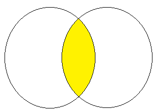

Inner join

```r
# Usando a função do R base `merge`
# Uma vez que os dois data frames têm uma mesma chave (id):

merge(df1, df2, by = "Id")
```

```
##   Id Partido         Estado
## 1  1      PT Rio de Janeiro
## 2  2      PT Rio de Janeiro
## 3  4    PSDB      São Paulo
## 4  6    PSDB      São Paulo
```

## Combinação exterior à esquerda (left outer)

- Retorna todas as linhas de **df1**, e todas as colunas de **df1** e **df2**. Para isso, utilizamos o parâmetro `all.x = TRUE`. Casos não correspondentes em **df2** apresentarão valores`NA` nas colunas deste objeto.

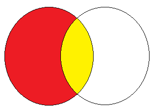

left outer join

```r
merge(df1, df2, by = "Id", all.x=TRUE)
```

```
##   Id Partido         Estado
## 1  1      PT Rio de Janeiro
## 2  2      PT Rio de Janeiro
## 3  3      PT           <NA>
## 4  4    PSDB      São Paulo
## 5  5    PSDB           <NA>
## 6  6    PSDB      São Paulo
```

## Combinação exterior à direita (right outer)

- Retorna todas as linhas de **df2**, e todas as colunas de **df2** e **df1**. Para isso, utilizamos o parâmetro `all.y = TRUE`. Da mesma forma que no exemplo anterior, casos não correspondentes em **df1** apresentarão valores`NA` nas colunas deste objeto.

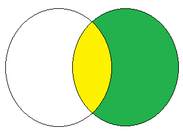

right outer join

```r
merge(df1, df2, by = "Id", all.y=TRUE)
```

```
##   Id Partido         Estado
## 1  1      PT Rio de Janeiro
## 2  2      PT Rio de Janeiro
## 3  4    PSDB      São Paulo
## 4  6    PSDB      São Paulo
## 5  7    <NA>       Brasília
```

## Combinação completa (full join)

[figure not shown]

```r
merge(df1, df2, by = "Id", all=TRUE)
```

```
##   Id Partido         Estado
## 1  1      PT Rio de Janeiro
## 2  2      PT Rio de Janeiro
## 3  3      PT           <NA>
## 4  4    PSDB      São Paulo
## 5  5    PSDB           <NA>
## 6  6    PSDB      São Paulo
## 7  7    <NA>       Brasília
```

## Usando as funções do pacote *dplyr*

```r
library(dplyr)
```

## Combinação natural (inner join)

- Retorna todas as linhas de **df1** onde há valores correspondentes em **df2**, mantendo as colunas de **df1** e **df2**.

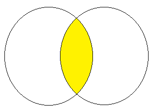

Inner join

```r
inner_join(df1, df2,  by = "Id")
```

```
##   Id Partido         Estado
## 1  1      PT Rio de Janeiro
## 2  2      PT Rio de Janeiro
## 3  4    PSDB      São Paulo
## 4  6    PSDB      São Paulo
```

## Combinação exterior à esquerda (left outer)

- Retorna todas as linhas de *df1*, e todas as colunas de *df1* e *df2*. Os casos não correspondentes em **df2** apresentarão valores`NA` nas colunas deste objeto.

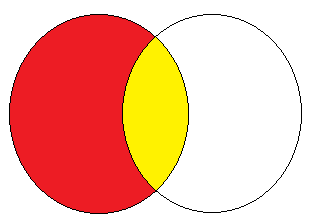

left outer join

```r
left_join(df1, df2,  by = "Id")
```

```
##   Id Partido         Estado
## 1  1      PT Rio de Janeiro
## 2  2      PT Rio de Janeiro
## 3  3      PT           <NA>
## 4  4    PSDB      São Paulo
## 5  5    PSDB           <NA>
## 6  6    PSDB      São Paulo
```

## Combinação exterior à direita (right outer)

- Retorna todas as linhas de *df2*, e todas as colunas de *df2* e *df1*. Os casos não correspondentes em **df1** apresentarão valores`NA` nas colunas deste objeto.

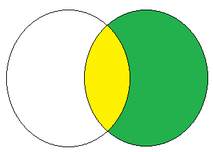

right outer join

```r
right_join(df1, df2,  by = "Id")
```

```
##   Id Partido         Estado
## 1  1      PT Rio de Janeiro
## 2  2      PT Rio de Janeiro
## 3  4    PSDB      São Paulo
## 4  6    PSDB      São Paulo
## 5  7    <NA>       Brasília
```

## Alternando a posição dos objetos

- Mesmo resultado que `right_join(df1, df2)`, mas com as colunas em posições diferentes.

```r
left_join(df2, df1,  by = "Id")
```

```
##   Id         Estado Partido
## 1  1 Rio de Janeiro      PT
## 2  2 Rio de Janeiro      PT
## 3  4      São Paulo    PSDB
## 4  6      São Paulo    PSDB
## 5  7       Brasília    <NA>
```

## Combinação completa (full join)

[figure not shown]

full join

```r
full_join(df1, df2,  by = "Id")
```

```
##   Id Partido         Estado
## 1  1      PT Rio de Janeiro
## 2  2      PT Rio de Janeiro
## 3  3      PT           <NA>
## 4  4    PSDB      São Paulo
## 5  5    PSDB           <NA>
## 6  6    PSDB      São Paulo
## 7  7    <NA>       Brasília
```

## Anti combinação (anti join)

- Retorna todas as linhas de *df1* onde não há valores correspondentes em *df2*, mas mantendo apenas colunas de *df1*.

[figure not shown]

anti join

```r
anti_join(df1, df2, by = "Id")
```

```
##   Id Partido
## 1  5    PSDB
## 2  3      PT
```

## Semi combinação (semi join)

- Retorna todas as linhas de *df1* onde há valores correspondentes em *df2*, mas mantendo apenas colunas de *df1*.

[figure not shown]

semi join

```r
semi_join(df1, df2,  by = "Id")
```

```
##   Id Partido
## 1  1      PT
## 2  2      PT
## 3  4    PSDB
## 4  6    PSDB
```